# Standardisation Test Results

20/04/2022

## Introduction

As part of the training of enumerators for the Product Access Initiative (PAI) project baseline coverage survey, an anthropometric standardisation test was conducted on the 20th of April 2022. A total of 24 enumerators took the test. Each enumerator measured the height and mid-upper arm circumference of 10 children once.

We analysed the measurements performed by the enumerators using metrics described by Ulijaszek and Kerr (1999). However, since only one set of measurements per enumerator per child was possible for this test, not all performance metrics could be performed. Of those that we present below, these results should be taken more as guidance for more focused support and training for the enumerators rather than a true picture of their capabilities.

## Summary metrics of height and MUAC measurements

Following are the summary metrics of height and MUAC measurements per child

| Child ID | Height Mean | Height Median | Height SD | Height IQR | MUAC Mean | MUAC Median | MUAC SD | MUAC IQR |
| --- | --- | --- | --- | --- | --- | --- | --- | --- |
| 1 | 71.32917 | 70.00 | 2.0543653 | 4.150 | 14.68750 | 14.50 | 0.7456031 | 1.125 |
| 2 | 74.98333 | 74.50 | 1.7489541 | 1.650 | 15.12917 | 15.10 | 0.4486493 | 0.800 |
| 3 | 70.18750 | 70.00 | 0.4839264 | 0.525 | 15.30000 | 15.30 | 0.5919753 | 0.725 |
| 4 | 70.20000 | 70.00 | 0.8283037 | 0.525 | 12.33333 | 12.30 | 0.3130032 | 0.325 |
| 5 | 71.22500 | 71.00 | 1.0579924 | 1.500 | 15.93750 | 15.80 | 0.5045984 | 0.750 |
| 6 | 68.52083 | 68.50 | 0.6978097 | 0.800 | 11.40417 | 11.40 | 0.3406888 | 0.325 |
| 7 | 66.87500 | 66.55 | 0.7242687 | 0.550 | 14.24167 | 14.20 | 0.5484497 | 0.475 |
| 8 | 71.60417 | 74.15 | 13.7291337 | 2.650 | 15.35417 | 15.35 | 0.6487306 | 0.600 |
| 9 | 82.01667 | 81.25 | 2.1548059 | 2.075 | 14.89167 | 14.80 | 0.2872912 | 0.225 |
| 10 | 90.97083 | 90.75 | 0.7195888 | 0.550 | 15.31250 | 15.40 | 0.4121128 | 0.325 |

## Detecting outlier measurements per child

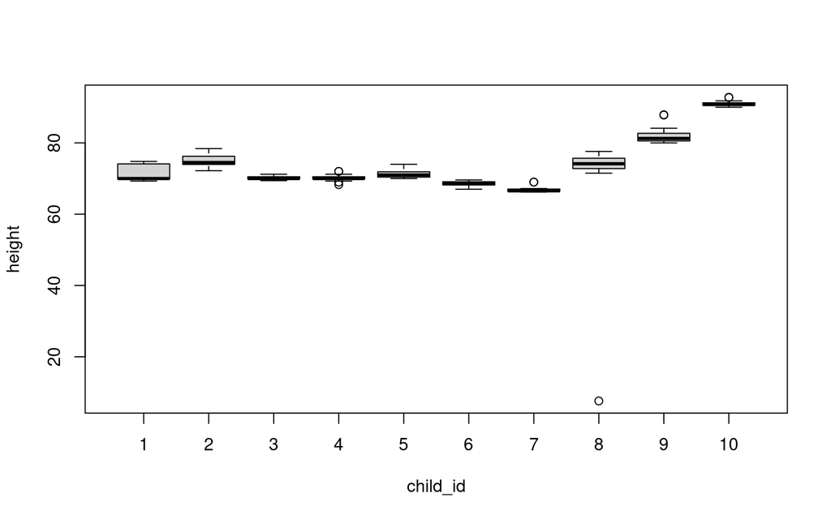

Boxplots of height measurements by enumerators per child

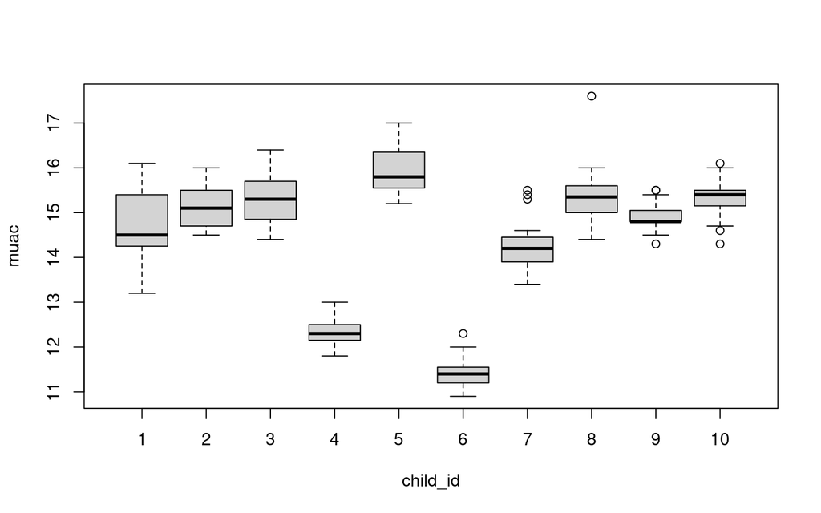

Following is a table of outlier height measurements performed by the enumerators:

| Enumerator ID | Number of outlier measurements |
| --- | --- |
| 2 | 1 |
| 3 | 1 |
| 6 | 2 |
| 13 | 1 |
| 14 | 1 |
| 17 | 2 |
| 18 | 2 |
| 23 | 1 |
| 24 | 2 |

Following is a table of outlier MUAC measurements performed by the enumerators:

| Enumerator ID | Number of outlier measurements |
| --- | --- |
| 5 | 1 |
| 6 | 1 |
| 7 | 2 |
| 11 | 2 |
| 12 | 1 |
| 19 | 2 |
| 20 | 2 |
| 23 | 2 |
| 24 | 2 |

## Measurement bias

We calculated measurement bias by getting the difference of an enumerator’s measurement of a child against the median of all the measurements for that child. We then got the mean of the measurement bias estimates for an enumerator per child measured to get overall measurement bias per enumerator. This was taken as a rough measure of an enumerator’s measurement accuracy.

Following are the results for each enumerator for measurement bias:

| Enumerator ID | Height Mean Bias | Height Classification | MUAC Mean Bias | MUAC Classification |
| --- | --- | --- | --- | --- |
| 1 | 1.12 | poor | 0.365 | rejected |
| 2 | 1.26 | poor | 0.395 | rejected |
| 3 | 0.94 | poor | 0.165 | acceptable |
| 4 | 0.40 | acceptable | 0.245 | poor |
| 5 | 0.75 | poor | 0.265 | poor |
| 6 | 7.12 | rejected | 0.225 | poor |
| 7 | 1.73 | rejected | 0.565 | rejected |
| 8 | 1.73 | rejected | 0.305 | rejected |
| 9 | 0.47 | acceptable | 0.285 | poor |
| 10 | 0.70 | poor | 0.345 | rejected |
| 11 | 0.55 | acceptable | 0.605 | rejected |
| 12 | 0.56 | acceptable | 0.625 | rejected |
| 13 | 0.74 | poor | 0.215 | poor |
| 14 | 0.74 | poor | 0.195 | acceptable |
| 15 | 0.31 | good | 0.235 | poor |
| 16 | 0.31 | good | 0.225 | poor |
| 17 | 1.16 | poor | 0.255 | poor |
| 18 | 1.44 | rejected | 0.265 | poor |
| 19 | 0.60 | poor | 0.565 | rejected |
| 20 | 0.61 | poor | 0.545 | rejected |
| 21 | 0.46 | acceptable | 0.375 | rejected |
| 22 | 0.47 | acceptable | 0.385 | rejected |
| 23 | 1.59 | rejected | 0.445 | rejected |
| 24 | 1.97 | rejected | 0.485 | rejected |